# Text Mining Project

Haoran Wu

4/17/2024

# Introduction

This text mining project embarks on an extensive exploration of the narrative intricacies and thematic richness of L.M. Montgomery’s “The Blue Castle” and “Anne of Green Gables.” Montgomery, a pivotal figure in Canadian literature, is renowned for her vivid depictions of Prince Edward Island’s landscapes and the emotionally resonant stories of characters navigating the complexities of early 20th-century life. Her novels, widely celebrated for their depth of character and emotional insight, offer fertile terrain for a detailed linguistic and thematic analysis.

This project aims to systematically uncover patterns of word usage, sentiments, and character relationships that underpin Montgomery’s narrative techniques and thematic priorities. The analysis focuses on identifying how specific word choices and the frequency of these words contribute to the development of the novels’ themes such as personal identity, social conformity, and emotional resilience. Furthermore, sentiment analysis will highlight the emotional undertones across the novels, providing insights into how Montgomery uses language to evoke feelings and forge connections with her readers.

By mapping out the most common bigrams—pairs of words that frequently appear adjacent to each other—the study will also shed light on the dynamic interactions between characters, revealing underlying social structures and individual character arcs. This analytical approach not only enhances our understanding of Montgomery’s stylistic choices but also deepens our appreciation of how her narrative strategies reflect and respond to the societal norms and challenges of her era.

Through this extensive textual analysis, the project aims to contribute valuable insights to academic discussions about Montgomery’s literary legacy, providing a richer understanding of her contributions to not only Canadian literature but also to the depiction of complex social and personal themes through the art of storytelling.

# Methodology

## Data Resourse

[Project Gutenberg](https://www.gutenberg.org/) is a valuable resource offering over 60,000 free eBooks, making it an indispensable tool for digital humanities projects. For my analysis, I will explore two notable works by L.M. Montgomery: The Blue Castle and Anne of Green Gables. These texts, chosen for their rich narrative and thematic depth, are accessible on Project Gutenberg with EBook numbers 67979 and 45, respectively. This accessibility allows for an extensive textual analysis using advanced computational tools.

## Packages

For this project, I will download Montgomery’s novels in UTF-8 encoded texts using the `gutenbergr` package developed by [David Robinson](http://varianceexplained.org/). This package facilitates easy access to a vast repository of over 60,000 free eBooks available on Project Gutenberg. In addition to `gutenbergr`, my analysis will leverage several other R packages crucial for data manipulation and text analysis.

```r
library(tidyverse)
library(purrr)
library(tidytext)
library(gutenbergr)
```

The `tidyverse` suite of packages, known for its powerful data manipulation and visualization capabilities, will be instrumental in organizing and displaying data. The `tidyr` and `dplyr` components of `tidyverse` will particularly help in reshaping and summarizing the datasets. For text mining tasks, such as tokenization and sentiment analysis, I will utilize the `tidytext` package, which integrates well with the tidy data principles of `tidyverse` and simplifies text processing in R. Additionally, `purrr` will be used to enhance list processing capabilities, aiding in efficient data handling and iteration across various text analysis functions. These tools collectively provide a robust framework for conducting thorough and insightful literary analysis.

```r
my_mirror <- "http://mirrors.xmission.com/gutenberg/"

my_mirror <- "http://mirrors.xmission.com/gutenberg/"

Montgomery<-gutenberg_download(c(67979,45), mirror = my_mirror)
```

```r
sunzi<- gutenberg_download(45)
```

```
## Determining mirror for Project Gutenberg from https://www.gutenberg.org/robot/harvest
```

```
## Using mirror http://aleph.gutenberg.org
```

# Data Cleaning and Preparation

In the data cleaning and preparation phase of my text mining project, I employ the `tidytext` package, specifically using the `unnest_tokens` function to break down the text of L.M. Montgomery’s novels into individual words, or tokens. This step transforms each row of text into separate rows for each word in the new dataframe, referred to here as `tidy_Montgomery`. Following tokenization, I utilize an `anti_join` function to remove common stop words, which are typically frequent but carry little unique textual significance, thus focusing the analysis on more meaningful words. After cleaning, a frequency count of the remaining words is performed using `dplyr::count`, sorting the results to identify the most prevalent terms. The result is a tibble displaying the frequency of each word, with ‘anne’, ‘valancy’, and ‘marilla’ appearing as some of the most frequent words, indicating their significance in the narratives of “Anne of Green Gables” and “The Blue Castle”. This methodical approach ensures that the analysis is concentrated on the text’s most impactful elements.

```r
tidy_Montgomery <- Montgomery %>%
  unnest_tokens(word, text) %>%
  anti_join(stop_words)
#stop_words
```

```r
tidy_Montgomery %>%
  dplyr::count(word, sort = TRUE)
```

```
## # A tibble: 10,428 × 2
##    word        n
##    <chr>   <int>
##  1 anne     1109
##  2 valancy   978
##  3 marilla   797
##  4 i’m       460
##  5 don’t     455
##  6 diana     386
##  7 it’s      341
##  8 matthew   339
##  9 barney    315
## 10 time      275
## # ℹ 10,418 more rows
```

# Data Analysis

## Frequency Analysis

In the frequency analysis stage of my project, I conducted a thorough examination of the most common words found in L.M. Montgomery’s novels, specifically focusing on The Blue Castle and Anne of Green Gables. After removing stop words—which are commonly used words that offer little value in the way of context or differentiation—the data was processed to highlight the most frequently occurring terms. The analysis revealed that words like “Anne,” “Valancy,” and “Marilla” are among the most frequent, indicating their central roles in the narratives.

To refine the analysis further, I filtered out contractions and common verbal phrases such as “I’m,” “don’t,” and “it’s,” which, despite their high frequency, do not provide significant insights into the thematic or narrative structure of the texts. The remaining words were then counted and sorted to identify the top 20, which were visualized using a bar chart with the words listed in descending order of frequency. This visualization not only illustrates the prominence of character names but also highlights terms that potentially signify key themes or elements within Montgomery’s work, such as “time,” “girl,” “eyes,” and “home.” This methodological approach offers a clear view of the linguistic patterns in Montgomery’s writing, shedding light on the characters and themes that dominate her novels.

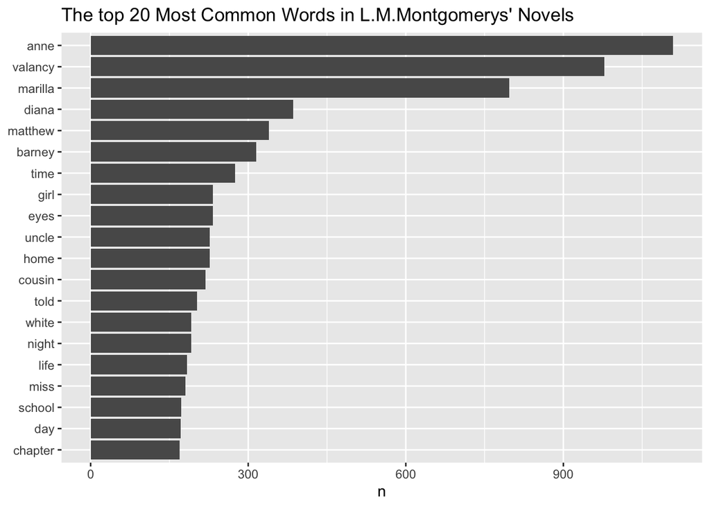

```r
v=c("i’m","don’t","it’s","didn’t","i’ve","i’ll","i’d","isn’t","can’t")
tidy_Montgomery %>%
  dplyr::count(word, sort = TRUE) %>%
  filter(n > 167) %>%
  filter(!word%in%v) %>%
  mutate(word = reorder(word, n)) %>%
  ggplot(aes(word, n)) +
  geom_col() +
  xlab(NULL) +
  coord_flip() + ggtitle("The top 20 Most Common Words in L.M.Montgomerys' Novels")
```

```r
topword<-tidy_Montgomery %>%
  dplyr::count(word, sort = TRUE) %>%
  filter(n > 200) %>%
  mutate(word = reorder(word, n))
topword<-topword[-c(9,35),]
```

## Sentiment in L.M. Montgomery’ Two Novels

`tidytext` package contains several sentiment lexicons, I am using [“bing”](https://www.cs.uic.edu/~liub/FBS/sentiment-analysis.html) for the following tasks.

In the sentiment analysis section of my text mining project on L.M. Montgomery’s novels The Blue Castle and Anne of Green Gables, I utilized the `tidytext` package, which provides access to multiple sentiment lexicons. For this specific analysis, I chose the [“bing”](https://www.cs.uic.edu/~liub/FBS/sentiment-analysis.html) due to its binary classification of words into positive and negative sentiments.

```r
bing_word_counts <- tidy_Montgomery %>%
  inner_join(get_sentiments("bing")) %>%
  dplyr::count(word, sentiment, sort = TRUE) %>%
  ungroup()
bing_word_counts
```

```
## # A tibble: 2,006 × 3
##    word      sentiment     n
##    <chr>     <chr>     <int>
##  1 miss      negative    180
##  2 love      positive    129
##  3 pretty    positive    126
##  4 afraid    negative    107
##  5 glad      positive     94
##  6 nice      positive     90
##  7 beautiful positive     85
##  8 hard      negative     81
##  9 bad       negative     80
## 10 lovely    positive     79
## # ℹ 1,996 more rows
```

The sentiment analysis process involved joining the tokenized text data with [“bing”](https://www.cs.uic.edu/~liub/FBS/sentiment-analysis.html) using the `inner_join` function. The resultant data frame, `bing_word_counts`, provided a detailed count of words associated with each sentiment category.

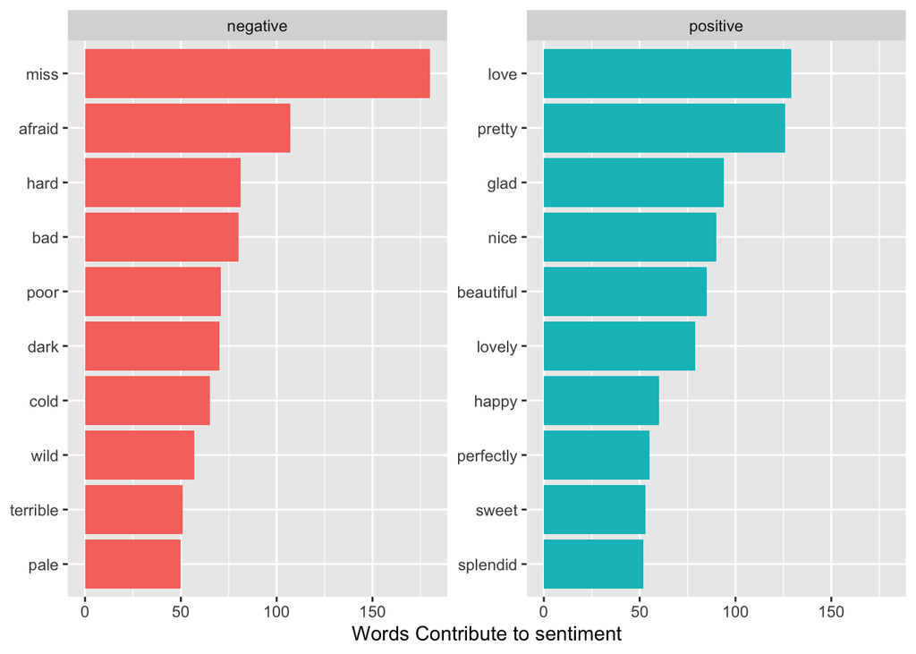

```r
bing_word_counts %>%
  group_by(sentiment) %>%
  top_n(10) %>%
  ungroup() %>%
  mutate(word = reorder(word, n)) %>%
  ggplot(aes(word, n, fill = sentiment)) +
  geom_col(show.legend = FALSE) +
  facet_wrap(~sentiment, scales = "free_y") +
  labs(y = "Words Contribute to sentiment",
       x = NULL) +
  coord_flip()
```

Analysis of the sentiment data revealed that “miss” and “love” were the most frequent negative and positive words, respectively. “Miss” often appeared in contexts reflecting societal pressures or personal challenges, particularly those faced by unmarried women, which are recurring themes in Montgomery’s novels. In contrast, “love” frequently appeared in scenarios depicting romance and personal affection, underscoring the positive relationships that are central to Montgomery’s narratives.

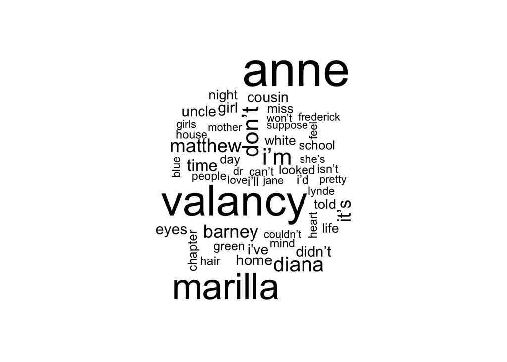

```r
library(wordcloud)
tidy_Montgomery %>%
  anti_join(stop_words) %>%
  dplyr::count(word) %>%
  with(wordcloud(word, n, max.words = 50))
```

A word cloud is an excellent tool for identifying trends and patterns in textual data. In the context of literary analysis, as applied in this project on L.M. Montgomery’s The Blue Castle and Anne of Green Gables, the word cloud provides a visual summary of the most significant words within the novels, offering insights into the predominant themes and character focus.

```r
library(reshape2)
```

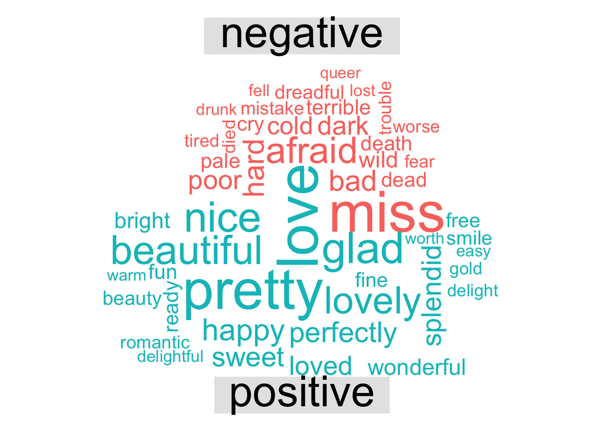

```r
tidy_Montgomery %>%
  inner_join(get_sentiments("bing")) %>%
  dplyr::count(word, sentiment, sort = TRUE) %>%
  acast(word ~ sentiment, value.var = "n", fill = 0) %>%
  comparison.cloud(colors = c("#F8766D", "#00BFC4"),
                   max.words = 50)
```

In the word cloud, words like “love,” “happy,” and “beautiful” dominate the positive spectrum, presented in bright and prominent formats. These words not only highlight the frequent occurrence of positive sentiments but also align with Montgomery’s recurring themes of romance, personal joy, and appreciation of beauty. On the other hand, the negative side of the spectrum is equally telling with words such as “afraid,” “miss,” and “cold” appearing prominently, reflecting the challenges, fears, and emotional struggles that the characters endure. This duality within the word cloud effectively mirrors the complex emotional landscapes that Montgomery creates, illustrating the blend of joy and adversity that characters face.

## Bigram Analysis

In my project on L.M. Montgomery’s The Blue Castle and Anne of Green Gables, I conducted a bigram analysis to explore common word pairings across the texts. This involved using the `unnest_tokens` function from the `tidytext` package to generate bigrams, which are pairs of adjacent words in the text. After initially extracting these bigrams, I applied additional cleaning to remove stop words and unnecessary elements, refining the dataset to focus on the most meaningful and frequent bigrams.

```r
Montgomery_bigrams <- Montgomery %>%
  unnest_tokens(bigram, text, token = "ngrams", n = 2)
Montgomery_bigrams
```

```
## # A tibble: 162,495 × 2
##    gutenberg_id bigram
##           <int> <chr>
##  1           45 anne of
##  2           45 of green
##  3           45 green gables
##  4           45 <NA>
##  5           45 by lucy
##  6           45 lucy maud
##  7           45 maud montgomery
##  8           45 <NA>
##  9           45 <NA>
## 10           45 <NA>
## # ℹ 162,485 more rows
```

```r
# Try to remove stop words then do the bigram
tidy_Montgomery <- Montgomery %>%
  unnest_tokens(word, text) %>%
  anti_join(stop_words)
library(tidyr)
bigrams_separated <- Montgomery_bigrams %>%
  separate(bigram, c("word1", "word2"), sep = " ")
bigrams_filtered <- bigrams_separated %>%
  filter(!word1 %in% stop_words$word) %>%
  filter(!word2 %in% stop_words$word)
bigram_counts <- bigrams_filtered %>%
  dplyr::count(word1, word2, sort = TRUE)
bigram_counts
```

```
## # A tibble: 13,881 × 3
##    word1   word2         n
##    <chr>   <chr>     <int>
##  1 <NA>    <NA>       4135
##  2 uncle   benjamin    103
##  3 cousin  stickles     95
##  4 green   gables       85
##  5 roaring abel         63
##  6 blue    castle       60
##  7 miss    stacy        55
##  8 uncle   james        53
##  9 cousin  georgiana    52
## 10 anne    shirley      43
## # ℹ 13,871 more rows
```

The cleaned data was then processed to count occurrences of each bigram, revealing notable pairs such as “Uncle Benjamin” and “Cousin Stickles” which frequently occur together. These particular bigrams highlight family relationships that are pivotal in Montgomery’s narratives, providing insight into character dynamics and their development within the stories.

```r
bigrams_united <- bigrams_filtered %>%
  unite(bigram, word1, word2, sep = " ")
bigrams_united
```

```
## # A tibble: 22,095 × 2
##    gutenberg_id bigram
##           <int> <chr>
##  1           45 green gables
##  2           45 NA NA
##  3           45 lucy maud
##  4           45 maud montgomery
##  5           45 NA NA
##  6           45 NA NA
##  7           45 NA NA
##  8           45 NA NA
##  9           45 rachel lynde
## 10           45 chapter ii
## # ℹ 22,085 more rows
```

Before visualize it, I have to make these bigram back to united.

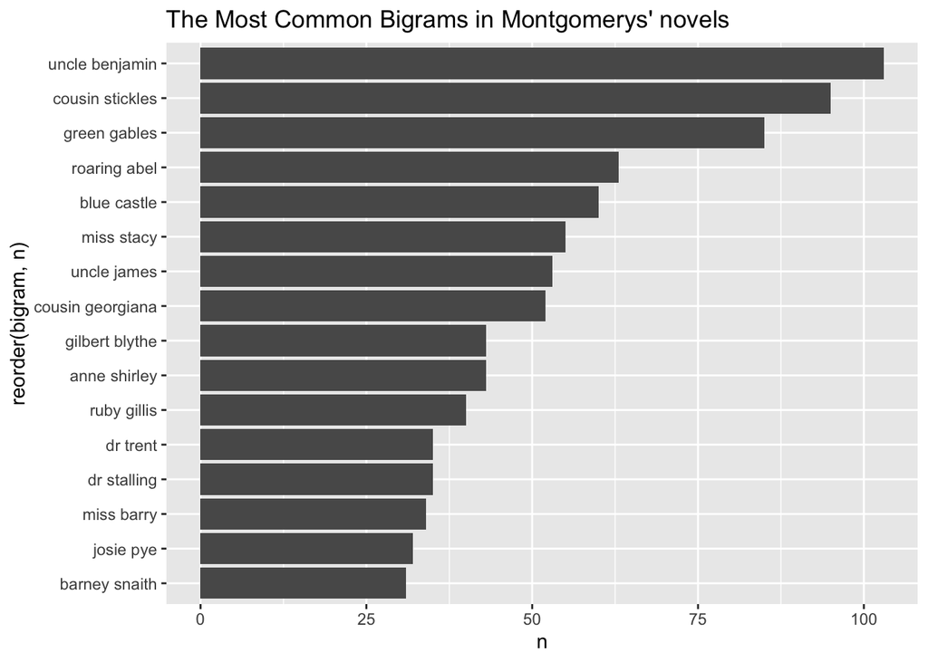

```r
# Problem for extra points to omit NA NA from the graph
bigram_tf_idf <- bigrams_united %>%
  dplyr::count(bigram)
bigram_tf_idf <- bigram_tf_idf %>% filter(n>30& n<1000)
ggplot(aes(x = reorder(bigram, n), y=n), data=bigram_tf_idf) + geom_bar(stat = 'identity') + ggtitle("The Most Common Bigrams in Montgomerys' novels") + coord_flip()
```

Yes, the most frequent bigrams in Montgomerys’ works are names.

```r
library(igraph)
bigram_graph <- bigram_counts %>%
  filter(n > 30) %>%
  graph_from_data_frame()
bigram_graph
```

```
## IGRAPH 5cd970e DN-- 29 17 --
## + attr: name (v/c), n (e/n)
## + edges from 5cd970e (vertex names):
##  [1] NA     ->NA        uncle  ->benjamin  cousin ->stickles  green  ->gables
##  [5] roaring->abel      blue   ->castle    miss   ->stacy     uncle  ->james
##  [9] cousin ->georgiana anne   ->shirley   gilbert->blythe    ruby   ->gillis
## [13] dr     ->stalling  dr     ->trent     miss   ->barry     josie  ->pye
## [17] barney ->snaith
```

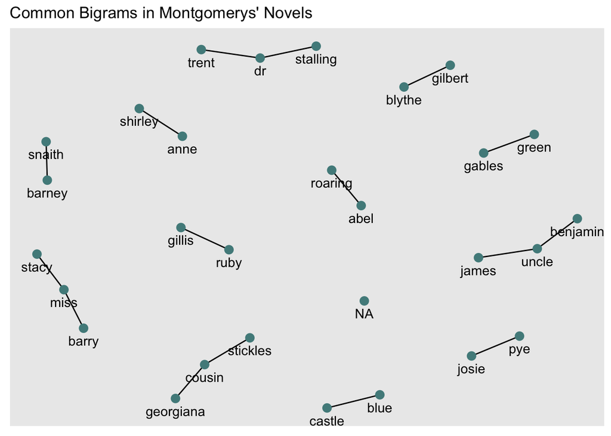

```r
library(ggraph)
set.seed(2017)

ggraph(bigram_graph, layout = "fr") +
  geom_edge_link() +
  geom_node_point(color = "darkslategray4", size = 3) +
  geom_node_text(aes(label = name), vjust = 1.8) + ggtitle("Common Bigrams in Montgomerys' Novels")
```

From this graph, some interesting points could be found:

The graph underscores relationships or frequent pairings such as “Anne Shirley” from Anne of Green Gables and “Gilbert Blythe,” her prominent counterpart.

The pair “Green Gables” is instantly recognizable as the setting of Montgomery’s famous novel Anne of Green Gables.

The bigram “Roaring Abel” encapsulating how Montgomery often embeds a character’s essence or reputation directly into their name.

Bigrams like “Uncle Benjamin” and “Cousin Georgiana” emphasize family relationships and their roles in the narratives. These relationships often play crucial roles in the development of the main characters and their adventures.

# Conclusions

The analysis of L.M. Montgomery’s “The Blue Castle” and “Anne of Green Gables” through advanced text mining techniques has provided a deeper insight into Montgomery’s literary craftsmanship and thematic exploration. By examining word frequency, sentiment analysis, and the relational dynamics between characters via bigrams, this project has highlighted the intricate ways in which Montgomery constructs her narratives and embeds deeper meanings within her texts.

Sentiment analysis further illustrated how Montgomery adeptly balances positive and negative emotions to create compelling narrative arcs. Words carrying positive sentiments frequently associated with themes of love, hope, and resilience, which are central to Montgomery’s narratives, highlighted her optimistic view of life’s potential. Conversely, the prevalence of negatively connotated words around themes such as isolation and societal pressure emphasized the challenges her characters must navigate, providing a realistic portrayal of the struggles inherent in personal growth and social acceptance.

In conclusion, this project has not only affirmed the enduring relevance of L.M. Montgomery’s work but has also showcased the potential of text mining in uncovering new layers of interpretation in classic literature. Montgomery’s novels, through their complex interplay of characters, themes, and linguistic choices, continue to offer valuable insights into the human condition and the transformative power of narrative. This analytical approach has opened up fresh avenues for appreciating Montgomery’s contribution to literature and has provided a quantitative backing to the qualitative aspects traditionally explored in literary studies.